# Exploring ClusterProfiler

Ben Mescher

author: “Ben Mescher”

Final, formal, paper write up is saved here: https://docs.google.com/document/d/1sDRhekkbcrHK-mQRN2IN-v70ZD0oT5KMHAc2F7OPLVA/edit?usp=sharing

This notebook contains miscellaneous explorations looking at the example GEO dataset used by Clusterprofiler (the data is actually from a different biocondoctor package: breastCancerMAINZ).

CluterProfiler has a great overview of this ‘gene set enrichment analysis’, labeling with GO or KEGG and identyifying predominant biological themes.

Manually choosing interesting clusters, and then perform “enrichment analysis” (annotate with function terms) is cumbersome. CluterProfiler compares and visualizes functional profiles among gene clusters.

http://bioconductor.org/packages/release/bioc/vignettes/clusterProfiler/inst/doc/clusterProfiler.html#supported-ontologiespathways

Finally, see if can use a bioconductor package, such as clusterProfiler, to group the data into category by GO Biological process. IDK how I can split into “pathways” like “p53 related”,etc. though. ClusterProfiler has nice visualizations, would be nice not to have to code those myself.

## First, run through examples with the provided dataset. Starting with trying to figure out how it was calculated:

#### From the documentation for DOSE…

- We computed the ratios of geometric means of grade III samples versus geometric means of grade I samples. Logarithm of these ratios (base 2) were stored in geneList dataset.
- that contained 200 samples, including 29 samples in grade I, 136 samples in grade II and 35 samples in grade III.

```r
library(breastCancerMAINZ)
data(mainz)
```

```r
#...this is how i THOUGHT a geometric mean should be calculated. but its totally not what the example code for creating sample dataset for DOSE package did!

grade.groups <- mainz@phenoData@data[,"grade"] #simpler way: pData(mainz)$grade
grade.groups
```

```
  [1] 2 3 3 2 2 2 2 3 2 1 2 2 2 2 2 3 2 2 2 2 1 2 2 2 2 3 2 3 1 1 2 2 2 3 2 2 2 3 1 2 3 2 2 2 2 3 2 2 1 2 2 2
 [53] 2 2 3 2 3 2 2 2 2 2 3 2 2 2 2 3 2 2 1 2 1 2 2 3 2 2 2 2 2 3 1 2 3 1 1 2 3 2 1 3 3 1 2 2 2 2 3 2 2 3 2 2
[105] 2 2 1 2 2 2 3 3 2 2 2 2 2 2 2 2 2 3 3 2 3 2 2 2 1 2 1 2 1 1 2 2 2 2 3 2 2 2 2 2 1 2 3 2 1 2 1 2 3 2 3 2
[157] 1 2 2 2 2 1 3 2 2 2 2 1 1 2 2 2 2 1 1 2 2 2 2 2 3 2 1 2 2 2 2 2 2 2 2 1 3 2 2 2 3 2 2 2
```

```r
length(grade.groups)
```

```
[1] 200
```

```r
test.exprs <- mainz@assayData[["exprs"]][,grade.groups == 1]# | grade.groups == 3)]
head(test.exprs)[,1:5]
```

```
          MAINZ_BC6011 MAINZ_BC6024 MAINZ_BC6032 MAINZ_BC6033 MAINZ_BC6044
1007_s_at    11.725876    11.162496    11.970502    11.166585    11.595021
1053_at       8.151481     8.494755     8.522063     8.636343     8.471718
117_at        4.240336     6.952299     7.698116     7.432285     7.501584
121_at        9.300117     9.448791     9.817451     9.376891     9.601830
1255_g_at     5.008374     4.767867     2.632580     3.575176     4.565966
1294_at       9.568747     8.848641     9.930047     8.600699     8.999343
```

```r
denom <- (1/length(which(grade.groups == 1)))[1]
x <- as.matrix(as.matrix(apply(test.exprs,1,prod))^denom)
x[1:5]
```

```
[1] 11.866206  8.355991  7.318369  9.762078  4.924242
```

```r
test.exprs2 <- mainz@assayData[["exprs"]][,grade.groups == 3]# | grade.groups == 3)]
head(test.exprs2)[,1:5]
```

```
          MAINZ_BC6002 MAINZ_BC6003 MAINZ_BC6008 MAINZ_BC6017 MAINZ_BC6029
1007_s_at    12.860578    12.047634    11.565278    11.692314    11.620683
1053_at       8.656013     8.592693     8.904414     8.679955     9.448961
117_at        7.702192     7.479278     7.499551     8.483382     7.203623
121_at        9.586913     9.297300     9.061995     8.722111    10.165988
1255_g_at     5.610451     4.588868     4.100552     2.907951     5.931134
1294_at       8.399767     8.884104     8.493093     8.557537     9.068023
```

```r
denom2 <- (1/length(which(grade.groups == 3)))[1]
y <- as.matrix(as.matrix(apply(test.exprs2,1,prod))^denom2)
y[1:5]
```

```
[1] 11.856486  9.106470  7.771627  9.716578  4.378273
```

```r
z <- as.matrix(log2(y / x))


#test.exprs["204475_at",]
#test.exprs2["204475_at",]
```

```r
x["204475_at",1]
```

```
204475_at
 4.974261
```

```r
y["204475_at",1]
```

```
204475_at
 8.301158
```

```r
#what is gene 4312? 204475_at
#value in "genelist" example data...4.572613

y["204475_at",1] / x["204475_at",1]
```

```
204475_at
 1.668822
```

```r
log2(4.97)
```

```
[1] 2.313246
```

```r
log2(8.3)
```

```
[1] 3.053111
```

```r
#geneList #2nd gene was 8318, with a ratio of 4.514
#id is 204126_s_at
x["204126_s_at",1]
```

```
204126_s_at
   3.988809
```

```r
y["204126_s_at",1]
```

```
204126_s_at
   7.100198
```

```r
y["204126_s_at",1] / x["204126_s_at",1]
```

```
204126_s_at
    1.78003
```

```r
log2(1.78)
```

```
[1] 0.8318772
```

```r
#still not able to really recreate the sample datasets values?
```

```r
log2(y/x)["204126_s_at",]
```

```
204126_s_at
  0.8319015
```

```r
#as.matrix(sort(as.matrix(log2(y/x)),decreasing=TRUE ))
```

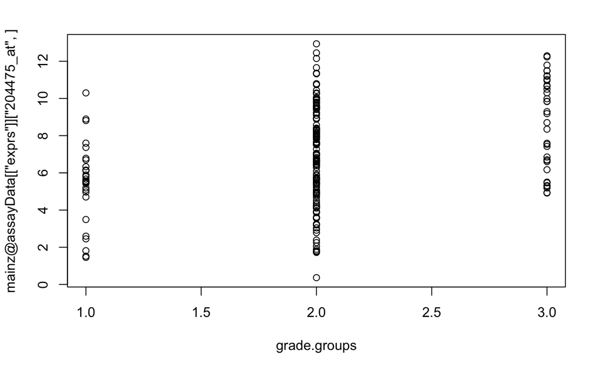

```r
#head(log2(y / x))
plot(mainz@assayData[["exprs"]]["204475_at",] ~ grade.groups) #first gene in genelist (stg 3 higher)
```

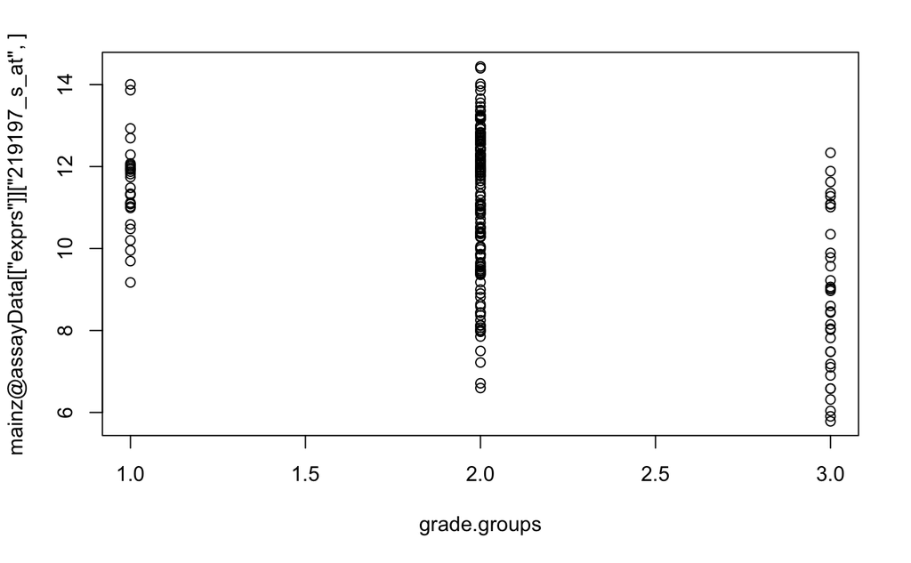

```r
plot(mainz@assayData[["exprs"]]["219197_s_at",] ~ grade.groups) #one of the last genes in geneLIst (stg 1 higher)
```

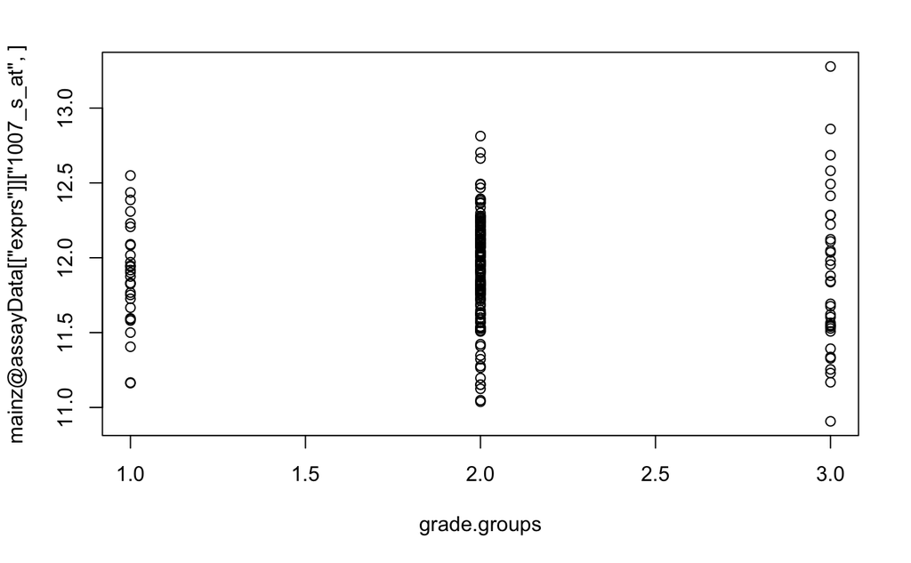

```r
plot(mainz@assayData[["exprs"]]["1007_s_at",] ~ grade.groups) #first row in expression source data
```

```r
#mainz@assayData[["exprs"]][,grade.groups == 1]["204475_at",]
```

```r
(y[1:10])
```

```
 [1] 11.856486  9.106470  7.771627  9.716578  4.378273  8.774180  7.440109  5.662400 10.227855  5.364836
```

```r
(x[1:10])
```

```
 [1] 11.866206  8.355991  7.318369  9.762078  4.924242  9.295710  7.329188  5.701419  8.955485  6.104223
```

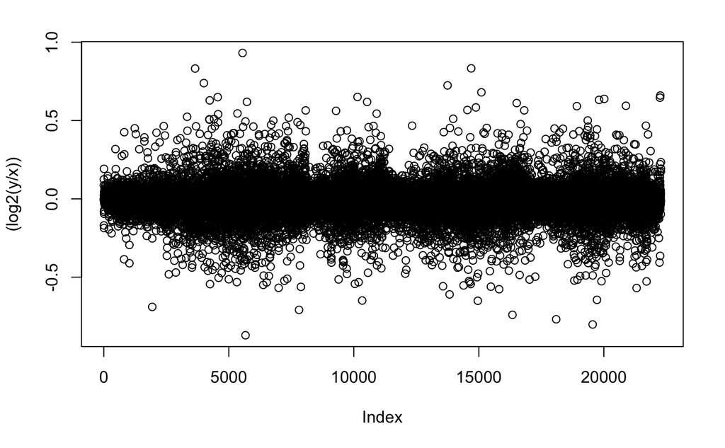

```r
plot((log2(y / x)))
```

```r
library(DOSE)
data(geneList) #loads the pre-saved named vector "geneList", which is ordered by value.
```

## So, I was way off above! (trying to figure out how the test dataset was calculated)

```r
as.matrix(geneList[1:5]) #when you use the subscript slice... doesnt display with the names, unless you use "as.matrix"!!!
```

```
          [,1]
4312  4.572613
8318  4.514594
10874 4.418218
55143 4.144075
55388 3.876258
```

```r
as.matrix(geneList[12485:12495])
```

```
           [,1]
11122 -3.122271
55351 -3.240869
9     -3.250120
4239  -3.261099
5241  -3.297730
10551 -3.330760
10974 -3.416798
79838 -3.457221
79901 -3.603467
57758 -3.945467
4969  -4.302655
```

#### A challenge is to always use the internal IDs, not the entrez ID. Even came up here, when looking at the toy dataset for Mainz!

#### after locaitng a gene to debug and compare results… had to use lots of plots to see distribution of values (was this dataset already normalized? etc.)

```r
# FINALLY, mapped back to internal id: 204475_at from entrez id for MMP1
mainz@featureData@data[which(data.frame(mainz@featureData@data)[,"Gene.ID"]=="4312"),]
```

|  | probe | Gene.title | Gene.symbol | Gene.ID | EntrezGene.ID | UniGene.title | UniGene.symbol | UniGene.ID | Nucleotide.Title | GI | GenBank.Accession | Platform_CLONEID | Platform_ORF | Platform_SPOTID | Chromosome.location | Chromosome.annotation | GO.Function | GO.Process | GO.Component | GO.Function.1 | GO.Process.1 | GO.Component.1 |
| --- | --- | --- | --- | --- | --- | --- | --- | --- | --- | --- | --- | --- | --- | --- | --- | --- | --- | --- | --- | --- | --- | --- |
| 204475_at | 204475_at | matrix metallopeptidase 1 (interstitial collagenase) | MMP1 | 4312 | 4312 | NA | NA | NA | Homo sapiens matrix metallopeptidase 1 (interstitial collagenase) (MMP1), transcript variant 1, mRNA | 225543092 | NM_002421 | NA | NA | NA | 11q22.3 | Chromosome 11, NC_000011.9 (102660651..102668894, complement) | calcium ion binding///metalloendopeptidase activity///peptidase activity///zinc ion binding | collagen catabolic process///interspecies interaction between organisms///metabolic process///proteolysis | extracellular region///proteinaceous extracellular matrix | GO:0005509///GO:0004222///GO:0008233///GO:0008270 | GO:0030574///GO:0044419///GO:0008152///GO:0006508 | GO:0005576///GO:0005578 |

```r
mainz@featureData@data[which(data.frame(mainz@featureData@data)[,"Gene.ID"]=="57758"),]
```

|  | probe | Gene.title | Gene.symbol | Gene.ID | EntrezGene.ID | UniGene.title | UniGene.symbol | UniGene.ID | Nucleotide.Title | GI | GenBank.Accession | Platform_CLONEID | Platform_ORF | Platform_SPOTID | Chromosome.location | Chromosome.annotation | GO.Function | GO.Process | GO.Component | GO.Function.1 | GO.Process.1 | GO.Component.1 |
| --- | --- | --- | --- | --- | --- | --- | --- | --- | --- | --- | --- | --- | --- | --- | --- | --- | --- | --- | --- | --- | --- | --- |
| 219197_s_at | 219197_s_at | signal peptide, CUB domain, EGF-like 2 | SCUBE2 | 57758 | 57758 | NA | NA | NA | te95c06.x1 NCI_CGAP_Pr28 Homo sapiens cDNA clone IMAGE:2094442 3-, mRNA sequence | 4270174 | AI424243 | NA | NA | NA | 11p15.3 | Chromosome 11, NC_000011.9 (9041935..9113155, complement) | calcium ion binding | NA | extracellular region | GO:0005509 | NA | GO:0005576 |

```r
mainz@featureData@data[which(data.frame(mainz@featureData@data)[,"Gene.ID"]=="8318"),]
```

|  | probe | Gene.title | Gene.symbol | Gene.ID | EntrezGene.ID | UniGene.title | UniGene.symbol | UniGene.ID | Nucleotide.Title | GI | GenBank.Accession | Platform_CLONEID | Platform_ORF | Platform_SPOTID | Chromosome.location | Chromosome.annotation | GO.Function | GO.Process | GO.Component | GO.Function.1 | GO.Process.1 | GO.Component.1 |
| --- | --- | --- | --- | --- | --- | --- | --- | --- | --- | --- | --- | --- | --- | --- | --- | --- | --- | --- | --- | --- | --- | --- |
| 204126_s_at | 204126_s_at | cell division cycle 45 homolog (S. cerevisiae) | CDC45 | 8318 | 8318 | NA | NA | NA | Homo sapiens cell division cycle 45 homolog (S. cerevisiae) (CDC45), transcript variant 2, mRNA | 34335230 | NM_003504 | NA | NA | NA | 22q11.21 | Chromosome 22, NC_000022.10 (19467416..19508135) | protein binding | DNA replication///DNA replication checkpoint///DNA-dependent DNA replication initiation///cell cycle | centrosome///cytoplasm///nucleoplasm///nucleus | GO:0005515 | GO:0006260///GO:0000076///GO:0006270///GO:0007049 | GO:0005813///GO:0005737///GO:0005654///GO:0005634 |

```r
#this is the internal ID of the Radich data for MMP1. Useless, but at first i was confused and thought the internal IDs in the mainz somehow was connected to some GO label that I would have to look up in Radich dataset
###gset@featureData@data[data.frame(gset@featureData@data)[,"Gene.ID"]=="4312",]
```

```r
###gset@featureData@data[data.frame(gset@featureData@data)[,"Gene.ID"]=="4312",]
```

Looking at the actual test dataset “geneList”, it appears to be distributed starting at +4.5

https://github.com/GuangchuangYu/DOSE/wiki/how-to-prepare-your-own-geneList

```r
#"In the following example, we selected fold change above 1 as the differential genes and analyzing their disease association."
gene <- names(geneList)[abs(geneList) > 1.5]
head(geneList)
```

```
    4312     8318    10874    55143    55388      991
4.572613 4.514594 4.418218 4.144075 3.876258 3.677857
```

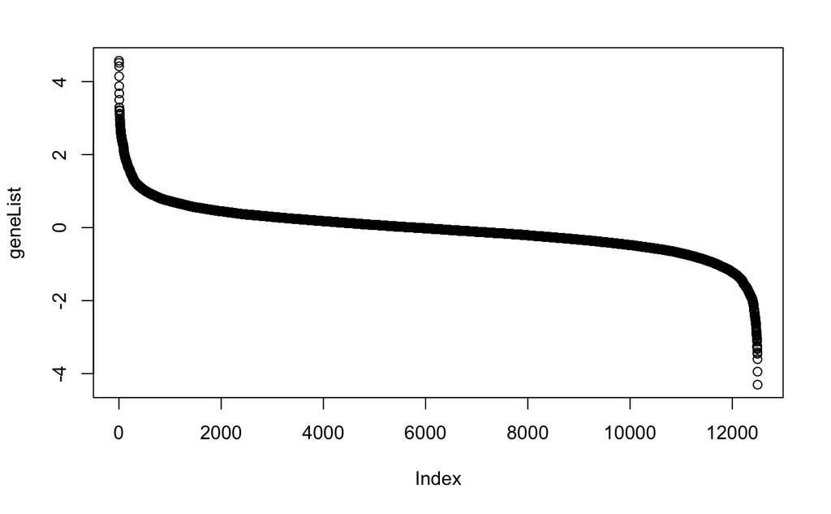

```r
plot(geneList)
```

#### later: found source code used to actually create the geneList!!!

- Formula they used for “geometic means” is not what I expected
- Also, most of the work here is converting from internal to Entrez IDs (though nowadays, you could use the bitr function for that! maybe?)
- raw data creates 22k elements. but only 12k have a labeled entrez ID and get saved to the final dataset!
- https://github.com/GuangchuangYu/DOSE/blob/master/inst/extdata/preparing.geneList.R

```r
clmainz=mainz@phenoData$grade

dd <- mainz@assayData[["exprs"]]
g1 <- dd[,clmainz == 1]
g3 <- dd[,clmainz == 3]
#interesting how they calculate the geometric mean as log2(e^mean of every row / e^mean of every row)...
#rowMeans(g3)["204475_at"]
#rowMeans(g1)["204475_at"]
#^^result is 8.6 and 5.49, when you do "exp" of both, the log2 is ~4+ !!
geneListExample <- exp(rowMeans(g3))/exp(rowMeans(g1))
geneListExample <- sort(geneListExample, decreasing=TRUE)
geneListExample <- log(geneListExample, base=2)
head(geneListExample)
```

```
  204475_at 204126_s_at   206023_at 221520_s_at 202917_s_at 220651_s_at
   4.572613    4.514594    4.418218    4.144075    4.060795    3.876258
```

```r
#^creates numeric list (named), but the names are all the internal IDs (204475_at, not Entrez ID integers)

#the rest of the code is to replace internal IDs like "204475_at" with the entrez integer IDs (from hgu133a file)
#this is from github, years ago. clusterProfiler uses a somewhat newer method to do this: bitr()
#require("hgu133a.db")
#require(siggenes)
#eg <- mget(names(geneList), hgu133aENTREZID, ifnotfound=NA) #supposed to retreive entrez ids
#gg <- data.frame(probe=names(geneList), val = geneList)
#eg.df <- data.frame(probe=names(eg), eg=unlist(eg))
#
#xx <- merge(gg, eg.df, by.x="probe", by.y="probe")
#xx <- xx[,-1]
#xx <- unique(xx)
#xx <- xx[!is.na(xx[,2]),]
#
#require(plyr)
#yy <- ddply(xx, .(eg), function(x) data.frame(val=mean(x$val)))
#
#geneList <- yy$val
#names(geneList) <- yy$eg
#geneList <- sort(geneList, decreasing=TRUE)
#
#save(geneList, file="geneList.rda")
```

```r
#Example use of DOSE() enrichment analysis
gene <- names(geneList)[abs(geneList) > 1.5]
x <- enrichDO(gene          = gene,
              ont           = "DO",
              pvalueCutoff  = 0.05,
              pAdjustMethod = "BH",
              universe      = names(geneList),
              minGSSize     = 5,
              maxGSSize     = 500,
              qvalueCutoff  = 0.05,
              readable      = TRUE)
head(x)
```

|  | ID | Description | GeneRatio | BgRatio | pvalue | p.adjust | qvalue | geneID | Count |
| --- | --- | --- | --- | --- | --- | --- | --- | --- | --- |
| DOID:170 | DOID:170 | endocrine gland cancer | 48/331 | 472/6268 | 5.662129e-06 | 0.004784499 | 0.003826407 | NMU/TOP2A/CRABP1/RRM2/UBE2C/MSLN/BIRC5/S100P/EZH2/KIF20A/CCNB1/PTTG1/MCM2/CDC25A/PLK1/MMP9/CXCL8/CTSV/NKX2-2/GGH/HMGA1/TFPI2/RAD51/APLP1/CCNE1/PCLAF/MKI67/IKBKB/F3/AKAP12/AGTR1/TGFB3/HTR2B/GSTT1/PLAT/… | 48 |
| DOID:10283 | DOID:10283 | prostate cancer | 40/331 | 394/6268 | 3.859157e-05 | 0.013921739 | 0.011133923 | MMP1/S100A9/S100A8/BCL2A1/CXCL10/BIRC5/S100P/EZH2/MMP12/NUDT…… | 40 |
| DOID:3459 | DOID:3459 | breast carcinoma | 37/331 | 357/6268 | 4.942629e-05 | 0.013921739 | 0.011133923 | MMP1/S100A9/S100A8/TOP2A/NEK2/CCNA2/MAD2L1/BIRC5/S100P/AURKA…… | 37 |
| DOID:3856 | DOID:3856 | male reproductive organ cancer | 40/331 | 404/6268 | 6.821467e-05 | 0.014410349 | 0.011524689 | MMP1/S100A9/S100A8/BCL2A1/CXCL10/BIRC5/S100P/EZH2/MMP12/NUDT…… | 40 |
| DOID:824 | DOID:824 | periodontitis | 16/331 | 109/6268 | 1.699304e-04 | 0.018859464 | 0.015082872 | MMP1/S100A8/CAMP/IL1R2/MMP12/IL12RB2/MMP9/LYZ/CXCL8/CTLA4/CCL5/PROM1/AGTR1/GSTT1/PLAT/TNFRSF11B | 16 |
| DOID:3905 | DOID:3905 | lung carcinoma | 43/331 | 465/6268 | 1.749754e-04 | 0.018859464 | 0.015082872 | MMP1/S100A9/FOXM1/CCNB2/S100A8/TOP2A/S100A7/RRM2/CEP55/UBE2C…… | 43 |

#### “The enrichDO function requires an entrezgene ID vector as input, mostly is the differential gene list of gene expression profile studies.”

If user needs to convert other gene ID type to entrezgene ID, we recommend using bitr function provided by clusterProfiler.

```r
#example from clusterProfile, for GO enrichment analysis...
library(clusterProfiler)
library(org.Hs.eg.db) #had to install separately
```

```r
gene <- names(geneList)[abs(geneList) > 2]
ggo <- groupGO(gene     = gene,
               OrgDb    = org.Hs.eg.db,
               ont      = "CC",
               level    = 3,
               readable = TRUE)
head(ggo)
```

|  | ID | Description | Count | GeneRatio | geneID |
| --- | --- | --- | --- | --- | --- |
| GO:0005886 | GO:0005886 | plasma membrane | 55 | 55/207 | S100A9/MELK/S100A8/MARCO/ASPM/CXCL10/LAMP3/CEP55/UGT8/UBE2C/…… |
| GO:0005628 | GO:0005628 | prospore membrane | 0 | 0/207 |  |
| GO:0005789 | GO:0005789 | endoplasmic reticulum membrane | 8 | 8/207 | FADS2/CDK1/CHODL/ITPR1/HLA-DQA1/CYP4F8/CYP4B1/FMO5 |
| GO:0019867 | GO:0019867 | outer membrane | 3 | 3/207 | BCL2A1/MAOB/PGR |
| GO:0031090 | GO:0031090 | organelle membrane | 18 | 18/207 | MARCO/BCL2A1/LAMP3/DUSP2/DTL/NUDT1/MAOB/ITPR1/FAM198B/HLA-DQA1/LRP2/CYP4F8/CYP4B1/LAMP5/FMO5/STEAP4/PGR/CYBRD1 |
| GO:0034357 | GO:0034357 | photosynthetic membrane | 0 | 0/207 |  |

```r
#KEGG Gene Set Enrichment Analysis
kk2 <- gseKEGG(geneList     = geneList,
               organism     = 'hsa',
               nPerm        = 1000,
               minGSSize    = 120,
               pvalueCutoff = 0.05,
               verbose      = FALSE)
head(kk2)
```

|  | ID | Description | setSize | enrichmentScore | NES | pvalue | p.adjust | qvalues | rank | leading_edge | core_enrichment |
| --- | --- | --- | --- | --- | --- | --- | --- | --- | --- | --- | --- |
| hsa04510 | hsa04510 | Focal adhesion | 188 | -0.4188582 | -1.717289 | 0.001410437 | 0.02139037 | 0.01388498 | 2183 | tags=27%, list=17%, signal=23% | 5228/7424/1499/4636/83660/7059/5295/1288/23396/3910/3371/308…… |
| hsa03013 | hsa03013 | RNA transport | 131 | 0.4116488 | 1.750568 | 0.002941176 | 0.02139037 | 0.01388498 | 3383 | tags=40%, list=27%, signal=29% | 10460/1978/55110/54913/9688/8894/11260/10799/9631/4116/5042/…… |
| hsa04218 | hsa04218 | Cellular senescence | 143 | 0.4153718 | 1.794389 | 0.002941176 | 0.02139037 | 0.01388498 | 1155 | tags=17%, list=9%, signal=16% | 2305/4605/9133/890/983/51806/1111/891/993/3576/1978/898/9134/4609/1869/1029/22808/3804/1871/5499/91860/292/1019/11200/1875 |
| hsa05152 | hsa05152 | Tuberculosis | 162 | 0.3745153 | 1.636120 | 0.003154574 | 0.02139037 | 0.01388498 | 2823 | tags=34%, list=23%, signal=27% | 820/51806/6772/64581/3126/3112/8767/3654/1054/1051/3458/1520…… |
| hsa05203 | hsa05203 | Viral carcinogenesis | 164 | 0.3523856 | 1.534653 | 0.003246753 | 0.02139037 | 0.01388498 | 3112 | tags=35%, list=25%, signal=26% | 991/890/983/1111/898/9134/6502/85236/1237/1029/8970/4067/295…… |
| hsa04062 | hsa04062 | Chemokine signaling pathway | 166 | 0.3747836 | 1.640109 | 0.003289474 | 0.02139037 | 0.01388498 | 1298 | tags=20%, list=10%, signal=19% | 3627/10563/6373/4283/6362/6355/2921/6364/3576/6352/10663/1230/6772/6347/6351/3055/1237/1236/4067/6354/114/3702/6361/1794/1234/6367/6375/6374/2919/409/4793/2792/6360/5880 |

```r
gene <- names(geneList)[abs(geneList) < 3]
ncg <- enrichNCG(gene)
head(ncg)
```

|  | ID | Description | GeneRatio | BgRatio | pvalue | p.adjust | qvalue | geneID | Count |
| --- | --- | --- | --- | --- | --- | --- | --- | --- | --- |
| soft_tissue_sarcomas | soft_tissue_sarcomas | soft_tissue_sarcomas | 28/1172 | 28/1571 | 0.0002517511 | 0.008056037 | 0.006360029 | 1029/999/6850/4914/4342/2185/55294/2041/4851/23512/2044/4058/5290/8726/4486/5297/5728/3815/2324/7403/5925/4763/1499/7157/5159/2045/3667/2066 | 28 |
| bladder | bladder | bladder | 61/1172 | 67/1571 | 0.0005108168 | 0.008173069 | 0.006452423 | 9700/2175/9603/1029/8997/688/1026/896/677/6256/55294/8085/48…… | 61 |
| glioma | glioma | glioma | 68/1172 | 76/1571 | 0.0008511747 | 0.009079196 | 0.007167787 | 4603/4609/1029/3418/8877/1019/7027/4613/1030/1956/1106/2264/…… | 68 |

```r
mkk2 <- gseMKEGG(geneList = geneList)
```

```
preparing geneSet collections...
GSEA analysis...
leading edge analysis...
done...
```

```r
head(mkk2)
```

|  | ID | Description | setSize | enrichmentScore | NES | pvalue | p.adjust | qvalues | rank | leading_edge | core_enrichment |
| --- | --- | --- | --- | --- | --- | --- | --- | --- | --- | --- | --- |
| M00337 | M00337 | Immunoproteasome | 15 | 0.7583644 | 2.008868 | 0.002341920 | 0.04476419 | 0.03618158 | 2516 | tags=80%, list=20%, signal=64% | 5688/5698/5721/5691/5685/5690/5684/5686/5699/5692/5683/5682 |
| M00340 | M00340 | Proteasome, 20S core particle | 13 | 0.7935026 | 2.002417 | 0.002392344 | 0.04476419 | 0.03618158 | 2516 | tags=92%, list=20%, signal=74% | 5688/5693/5691/5685/5690/5684/5686/5695/5692/5683/5694/5682 |
| M00354 | M00354 | Spliceosome, U4/U6.U5 tri-snRNP | 29 | 0.6053503 | 1.869772 | 0.002398082 | 0.04476419 | 0.03618158 | 2737 | tags=48%, list=22%, signal=38% | 6634/10907/6632/6636/57819/6637/25804/6628/10713/11157/51690/4809/6633/10465 |

#### In contrast to KEGG, WikiPathways is a continuously updated pathway database curated by a community of researchers and pathway enthusiasts.

I like WikiPathways because it has “RB pathway” in it.

```r
library(GSEABase)
library(tidyr)
```

```r
wpgmtfile <- system.file("extdata", "wikipathways-20180810-gmt-Homo_sapiens.gmt", package="clusterProfiler")
wp2gene <- read.gmt(wpgmtfile) #i had to install GSEAbase first ??
wp2gene <- wp2gene %>% tidyr::separate(ont, c("name","version","wpid","org"), "%")
wpid2gene <- wp2gene %>% dplyr::select(wpid, gene) #TERM2GENE
wpid2name <- wp2gene %>% dplyr::select(wpid, name) #TERM2NAME

ewp <- enricher(gene, TERM2GENE = wpid2gene, TERM2NAME = wpid2name)
ewp <- setReadable(ewp, org.Hs.eg.db, keyType = "ENTREZID")
head(ewp)
```

|  | ID | Description | GeneRatio | BgRatio | pvalue | p.adjust | qvalue | geneID | Count |
| --- | --- | --- | --- | --- | --- | --- | --- | --- | --- |
| WP481 | WP481 | Insulin Signaling | 155/4946 | 161/6249 | 2.628162e-10 | 9.881890e-08 | 5.449979e-08 | EIF4EBP1/GRB14/MAP4K2/MAP4K1/CBL/SLC2A1/MAPK13/RAC2/PRKCQ/MA…… | 155 |
| WP3888 | WP3888 | VEGFA-VEGFR2 Signaling Pathway | 221/4946 | 238/6249 | 3.091354e-09 | 5.811746e-07 | 3.205246e-07 | PBK/CXCL8/STAT1/CCL2/NDRG1/NCF2/CBL/BIN1/ICAM1/TXN/DKK1/TEAD…… | 221 |
| WP2380 | WP2380 | Brain-Derived Neurotrophic Factor (BDNF) signaling pathway | 138/4946 | 144/6249 | 7.914444e-09 | 9.195601e-07 | 5.071482e-07 | EIF4EBP1/STAT1/YBX1/EIF2S2/NCF2/DOCK3/SPP1/KCNA3/CDK5/NCK1/M…… | 138 |
| WP3932 | WP3932 | Focal Adhesion-PI3K-Akt-mTOR-signaling pathway | 281/4946 | 309/6249 | 9.782554e-09 | 9.195601e-07 | 5.071482e-07 | ITGB7/EIF4EBP1/ANGPT4/IL2RA/IL2RG/DDIT4/IL7R/COL11A2/SLC2A3/…… | 281 |
| WP3915 | WP3915 | Angiopoietin Like Protein 8 Regulatory Pathway | 127/4946 | 132/6249 | 1.403494e-08 | 1.055427e-06 | 5.820806e-07 | EIF4EBP1/SCD/MAP4K2/MAP4K1/CBL/SLC2A1/MAPK13/MAP2K1/MAP2K2/R…… | 127 |
| WP4172 | WP4172 | PI3K-Akt Signaling Pathway | 311/4946 | 345/6249 | 1.800697e-08 | 1.128437e-06 | 6.223462e-07 | ITGB7/EIF4EBP1/CCNE1/ANGPT4/CCNE2/IL2RA/MYC/COL9A3/IL2RG/PPP…… | 311 |

```r
#another wikipathways, this one has the PI3k/Akt/mTor pathway in it!
ewp2 <- GSEA(geneList, TERM2GENE = wpid2gene, TERM2NAME = wpid2name, verbose=FALSE)
ewp2 <- setReadable(ewp2, org.Hs.eg.db, keyType = "ENTREZID")
head(ewp2)
```

|  | ID | Description | setSize | enrichmentScore | NES | pvalue | p.adjust | qvalues | rank | leading_edge | core_enrichment |
| --- | --- | --- | --- | --- | --- | --- | --- | --- | --- | --- | --- |
| WP3932 | WP3932 | Focal Adhesion-PI3K-Akt-mTOR-signaling pathway | 281 | -0.3903410 | -1.653205 | 0.001347709 | 0.03542074 | 0.02935421 | 1994 | tags=26%, list=16%, signal=22% | THBS3/CAB39/IRS2/PRKAA2/PIK3R1/STK11/COL4A6/TEK/LAMA4/TNC/HG…… |
| WP306 | WP306 | Focal Adhesion | 188 | -0.4230017 | -1.719759 | 0.001398601 | 0.03542074 | 0.02935421 | 2221 | tags=28%, list=18%, signal=23% | MAPK3/PGF/VEGFC/CTNNB1/MYL5/TLN2/THBS3/PIK3R1/COL4A6/PIP5K1C…… |
| WP474 | WP474 | Endochondral Ossification | 59 | -0.5111776 | -1.746215 | 0.001647446 | 0.03542074 | 0.02935421 | 2142 | tags=47%, list=17%, signal=40% | DDR2/CAB39/RUNX2/PTH1R/CDKN1C/COL2A1/FGFR3/MGP/TGFB2/MEF2C/MMP13/IFT88/TIMP3/FGF2/ADAMTS5/SCIN/IGF1R/GHR/FGF18/ENPP1/GLI3/PTHLH/FRZB/PLAT/COL10A1/CST5/IGF1 |
| WP2911 | WP2911 | miRNA targets in ECM and membrane receptors | 21 | -0.6953475 | -1.955878 | 0.001672241 | 0.03542074 | 0.02935421 | 2629 | tags=76%, list=21%, signal=60% | ITGA1/THBS1/LAMC1/LAMA4/COL6A1/COL1A2/COL6A3/COL3A1/COL5A3/COL5A2/THBS2/ITGB5/COL5A1/COL6A2/LAMB2 |
| WP3668 | WP3668 | Hypothesized Pathways in Pathogenesis of Cardiovascular Disease | 24 | -0.6205206 | -1.778211 | 0.001721170 | 0.03542074 | 0.02935421 | 2183 | tags=42%, list=17%, signal=34% | SMAD3/RUNX2/CTGF/TGFBR2/LTBP2/POSTN/AGTR1/FBN1/TGFBR3 |
| WP4240 | WP4240 | Regulation of sister chromatid separation at the metaphase-anaphase transition | 14 | 0.8420478 | 2.214566 | 0.002320186 | 0.03542074 | 0.02935421 | 360 | tags=50%, list=3%, signal=49% | CDC20/CENPE/MAD2L1/PTTG1/BUB1B/ESPL1/BUB1 |

#### finally, try some visualizations from ClusterProfiler…

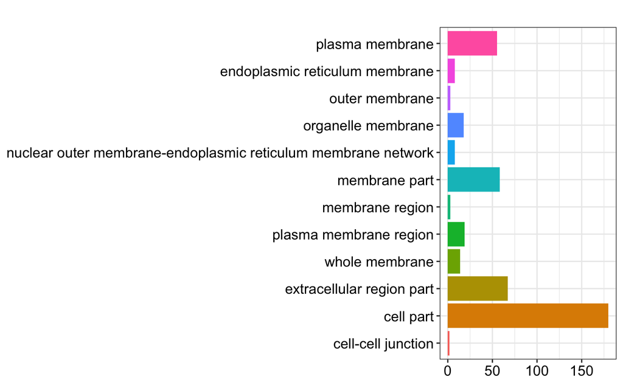

```r
barplot(ggo, drop=TRUE, showCategory=12)
```

```r
#gseaplot(mkk2, geneSetID = "hsa04145")
```

- unreleated enrichment resource, talking about evolutionary stuff: https://cran.r-project.org/web/packages/myTAI/vignettes/Expression.html
- notebook resource, Git + RMD https://github.com/rstudio/rmarkdown/issues/1020
- https://cran.r-project.org/web/packages/myTAI/vignettes/Enrichment.html